# Linear regression outliers

Author

Patrick A. Singleton

### Objectives & outcomes

The objectives of this tutorial are to:

- Understand what outliers are.
- Learn about different outlier detection methods, statistics, and graphs.
- Consider various ways of dealing with potential outliers.

At the end of this tutorial, you should be able to:

- Identify potential outliers using:
  - Leverage
  - Discrepancy (studentized residuals)
  - Influence (DFBETAS, DFFITS, Cook’s D)
  - A combination of the above methods
- Determine the appropriate remedy for outliers, depending upon your understanding of the dataset, data collection process, and analytic methods.

### Transportation dataset

For this tutorial, we will use data from the *2019 Winter Transprotation Survey data* project. The data (*tbaqsurvey*) include responses from a 6-day travel diary survey of adult residents of Cache Valley, Utah, specifically several outcomes related to individual daily activity participation and travel behavior. You can access these data from the [Transportation datasets](https://github.com/singletonpa/usu-course-transport-data-research/blob/main/Data/Transportation_datasets.md) page on GitHub.

```r
# Load data from GitHub
tbaqsurvey <- read.csv(file=url("https://raw.githubusercontent.com/singletonpa/usu-course-transport-data-safety/main/Data/TB_AQ_survey/tbaqsurvey.csv", method="libcurl"))

# Rename data frame
mydf <- tbaqsurvey
# str(tbaqsurvey)
```

```python
# Load packages
import pandas as pd
import numpy as np

# Changing setting until pandas 3.0
pd.options.mode.copy_on_write = True

# Load data from GitHub
tbaqsurvey = pd.read_csv("https://raw.githubusercontent.com/singletonpa/usu-course-transport-data-research/main/Data/TB_AQ_survey/tbaqsurvey.csv")

# Rename data frame
mydf = tbaqsurvey
# mydf.info()
```

To start, let’s create a linear regression model on this dataset. Instead of using factors, let’s use dummy variables:

```r
# Construct HHINC variables
mydf$HHINC_Below <- ifelse(is.na(mydf$HHINC3), NA, ifelse(mydf$HHINC3 %in% c("Less than $35,000", "$35,000 to $74,999"), 1, 0))
mydf$HHINC_Above <- ifelse(is.na(mydf$HHINC3), NA, ifelse(mydf$HHINC3=="$75,000 or more", 1, 0))
mydf$HHINC_Unknown <- ifelse(is.na(mydf$HHINC3), NA, ifelse(mydf$HHINC3=="Unknown", 1, 0))

# Linear regression model
mymod1 <- lm(MODE_TOT ~ HHNPER + HHINC_Above + HHINC_Unknown, data=mydf)
summary(mymod1)
```

```
Call:
lm(formula = MODE_TOT ~ HHNPER + HHINC_Above + HHINC_Unknown,
    data = mydf)

Residuals:
    Min      1Q  Median      3Q     Max
-3.6992 -2.2027 -0.2513  1.5041 15.5041

Coefficients:
              Estimate Std. Error t value Pr(>|t|)
(Intercept)    4.69186    0.20445  22.948   <2e-16 ***
HHNPER        -0.24460    0.09997  -2.447   0.0145 *
HHINC_Above    0.29324    0.12961   2.262   0.0238 *
HHINC_Unknown  0.49653    0.24126   2.058   0.0397 *
---
Signif. codes:  0 '***' 0.001 '**' 0.01 '*' 0.05 '.' 0.1 ' ' 1

Residual standard error: 2.433 on 1761 degrees of freedom
  (210 observations deleted due to missingness)
Multiple R-squared:  0.007, Adjusted R-squared:  0.005308
F-statistic: 4.138 on 3 and 1761 DF,  p-value: 0.006206
```

```python
# Construct HHINC variables
mydf["HHINC_Below"] = np.where(mydf["HHINC3"].isna(), np.nan,
    np.where(mydf["HHINC3"].isin(["Less than $35,000","$35,000 to $74,999"]), 1, 0))
mydf["HHINC_Above"] = np.where(mydf["HHINC3"].isna(), np.nan,
    np.where(mydf["HHINC3"]=="$75,000 or more", 1, 0))
mydf["HHINC_Unknown"] = np.where(mydf["HHINC3"].isna(), np.nan,
    np.where(mydf["HHINC3"]=="Unknown", 1, 0))

# Load packages
import statsmodels.formula.api as smf

# Linear regression model
mymod1 = smf.ols("MODE_TOT ~ HHNPER + HHINC_Above + HHINC_Unknown", data=mydf).fit()
mymod1.summary()
```

OLS Regression Results

| Dep. Variable: | MODE_TOT | R-squared: | 0.007 |
| --- | --- | --- | --- |
| Model: | OLS | Adj. R-squared: | 0.005 |
| Method: | Least Squares | F-statistic: | 4.138 |
| Date: | Sat, 04 Oct 2025 | Prob (F-statistic): | 0.00621 |
| Time: | 13:55:40 | Log-Likelihood: | -4071.5 |
| No. Observations: | 1765 | AIC: | 8151. |
| Df Residuals: | 1761 | BIC: | 8173. |
| Df Model: | 3 |  |  |
| Covariance Type: | nonrobust |  |  |

|  | coef | std err | t | P>\|t\| | [0.025 | 0.975] |
| --- | --- | --- | --- | --- | --- | --- |
| Intercept | 4.6919 | 0.204 | 22.948 | 0.000 | 4.291 | 5.093 |
| HHNPER | -0.2446 | 0.100 | -2.447 | 0.015 | -0.441 | -0.049 |
| HHINC_Above | 0.2932 | 0.130 | 2.262 | 0.024 | 0.039 | 0.547 |
| HHINC_Unknown | 0.4965 | 0.241 | 2.058 | 0.040 | 0.023 | 0.970 |

| Omnibus: | 468.584 | Durbin-Watson: | 1.277 |
| --- | --- | --- | --- |
| Prob(Omnibus): | 0.000 | Jarque-Bera (JB): | 1242.724 |
| Skew: | 1.395 | Prob(JB): | 1.40e-270 |
| Kurtosis: | 6.019 | Cond. No. | 9.89 |

Notes:  
[1] Standard Errors assume that the covariance matrix of the errors is correctly specified.

## Outliers and influential observations in regression

It is important to identify and address observations that may have a disproportionate impact on the linear regression model. If these observations do not belong (for one of several reasons), they will misrepresent the relationships being modeled and they should be removed. Influential observations are often termed **outliers** because they fall outside the normal range of IVs $X$, DV $Y$, or residuals $\epsilon$, or because they have an outsized impact on predicted outcomes $\hat Y$ or parameters $\beta$.

First, we will discuss methods to identify or detect the presence of outliers. Then, we will discuss options for dealing with outliers.

### Detection

There are three major types of detection methods that can help to identify outliers. The different methods look at different impacts that outliers might have, which (in some cases) tell us information about the type of outlier.

- **Leverage**: extreme values among set of independent variables
- **Discrepancy**: large difference between predicted and observed values of dependent variable
- **Influence**: large impact on estimated regression model parameters

#### Leverage

An observation has high **leverage ($h_{ii}$)** if it represents an extreme value (very far from the mean) of all independent variables in the model. For a model with one IV, leverage can be calculated as:

$$h_{ii} = \frac {1} {n} + \frac {(X_i - \bar X)^2} {\sum (X_i - \bar X)^2}$$

In for a general model with multiple IVs, matrix notation is used. Leverage values for each observation are given as the diagonals of the “hat” matrix $H = X (X^T X)^{-1} X^T$.

#### Discrepancy

An observation has a high discrepancy if it has a large difference between the observed DV and the predicted DV; i.e., if the observation’s residual is relatively large. The relative size of an observation’s residual can be calculated by dividing each residual by an estimate of the standard deviation, yielding what is called a studentized residual. For outlier detection, externally **studentized residuals $t_{i(i)}$** are investigated:

$$t_{i(i)} = \frac {\hat \epsilon_i} {\hat \sigma_{(i)} \sqrt {1 - h_{ii}}}$$

where the estimated standard deviation $\hat \sigma_{(i)}$ is calculated without the observation’s residual:

$$\hat \sigma_{(i)} = \frac {1} {n-(K+1)} \sum_{j=1, j\ne i}^{n} {\hat \epsilon_j^2}$$

Notice that the studentized residuals also depend upon the leverage $h_{ii}$.

#### Influence

An observation has high influence if the regression model’s predicted values or coefficients would change substantially if that observation were removed. There are three common measures of influence: **DFBETAS**, **DFFITS**, and **Cook’s distance**.

For each observation and each coefficient in the model, **DFBETAS** provides the difference in the parameter estimate if that observation were removed from the model:

$$DFBETA_{k, i} = \beta_k - \beta_{k,(i)}$$

For each observation, **DFFITS** provides the difference in the predicted values of the DV (Studentized) if that observation were removed from the model:

$$DFFITS_i = \frac {\hat Y_i - \hat Y_{i,(i)}} {s_{(i)} \sqrt {h_{ii}}}$$

where $s_{(i)}$ is the standard error without the observation.

An equivalent measure to DFFITS is called **Cook’s distance** or **Cook’s D**. For each observation, Cook’s D is a measure of the sum of all changes in the predicted values of the regression model if that observation were removed from the model:

$$D_i = \frac {\sum_{j=1}^n (\hat Y_i - \hat Y_{i,(i)})^2} {s^2 p} = \frac {\hat \epsilon_i^2} {s^2 p} [\frac {h_{ii}} {(1-h_{ii})^2}]$$

where $s^2$ is the mean square error of the model.

Notice that DFFITS and Cook’s D also both depend upon the leverage $h_{ii}$.

#### Examples

Don’t worry, you don’t have to code all of these outlier detection measures. We can use existing functions to do this for us.

You can do this with other functions in R: `hatvalues()`, `rstudent()`, `dfbeta()`, and `cooks.distance()`. You can look at the largest values numerically or visually:

```r
# Leverage (hat)
mymod_lev <- hatvalues(mymod1)
head(sort(mymod_lev, decreasing=T), n=10)
```

```
      731       732       733       734       735       736       737       740
0.0153525 0.0153525 0.0153525 0.0153525 0.0153525 0.0153525 0.0153525 0.0153525
      741       742
0.0153525 0.0153525
```

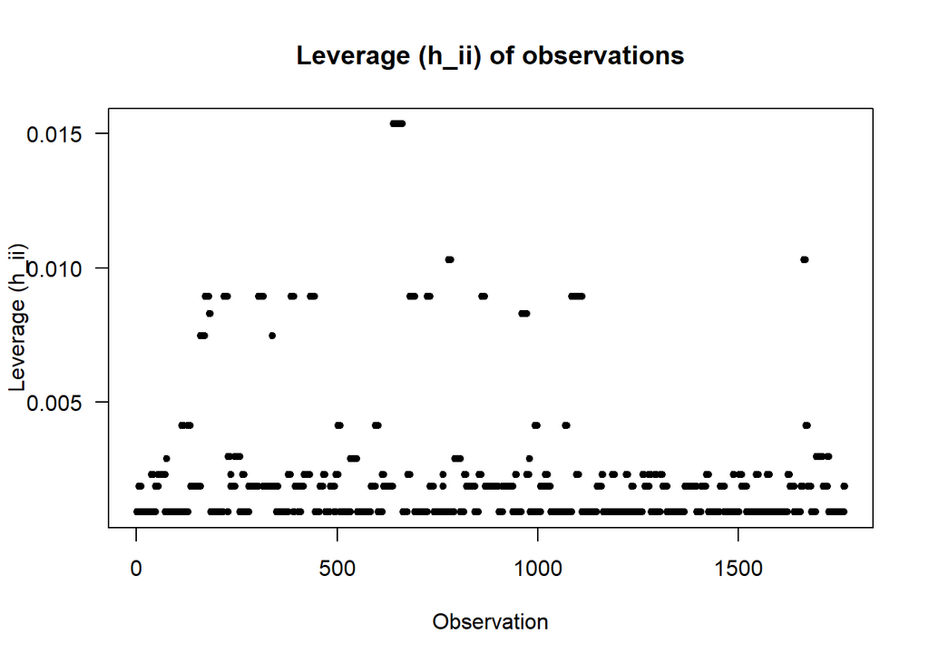

```r
plot(mymod_lev, pch=20, las=1,
     xlab="Observation", ylab="Leverage (h_ii)",
     main="Leverage (h_ii) of observations")
```

```r
# Discrepancy (studentized residuals)
mymod_dis <- rstudent(mymod1)
head(sort(abs(mymod_dis), decreasing=T), n=10)
```

```
    1567      503      893      780     1818      281      297      300
6.452353 5.538218 5.015689 4.694091 4.464274 4.030694 4.030694 4.030694
     710     1314
3.926445 3.926445
```

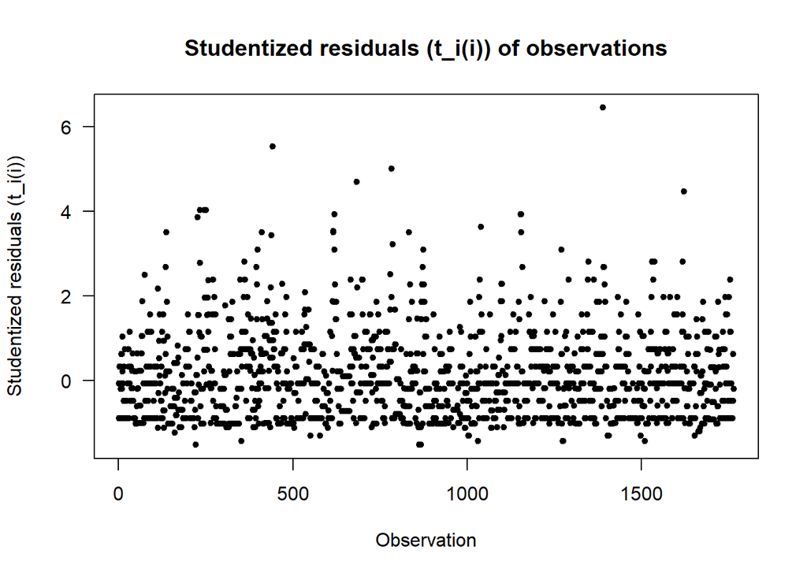

```r
plot(mymod_dis, pch=20, las=1,
     xlab="Observation", ylab="Studentized residuals (t_i(i))",
     main="Studentized residuals (t_i(i)) of observations")
```

```
       893        707        281        297        300        535       1256
0.03542246 0.03290814 0.02619782 0.02619782 0.02619782 0.02136512 0.02136512
      1257        143        280
0.02136512 0.01990928 0.01813587
```

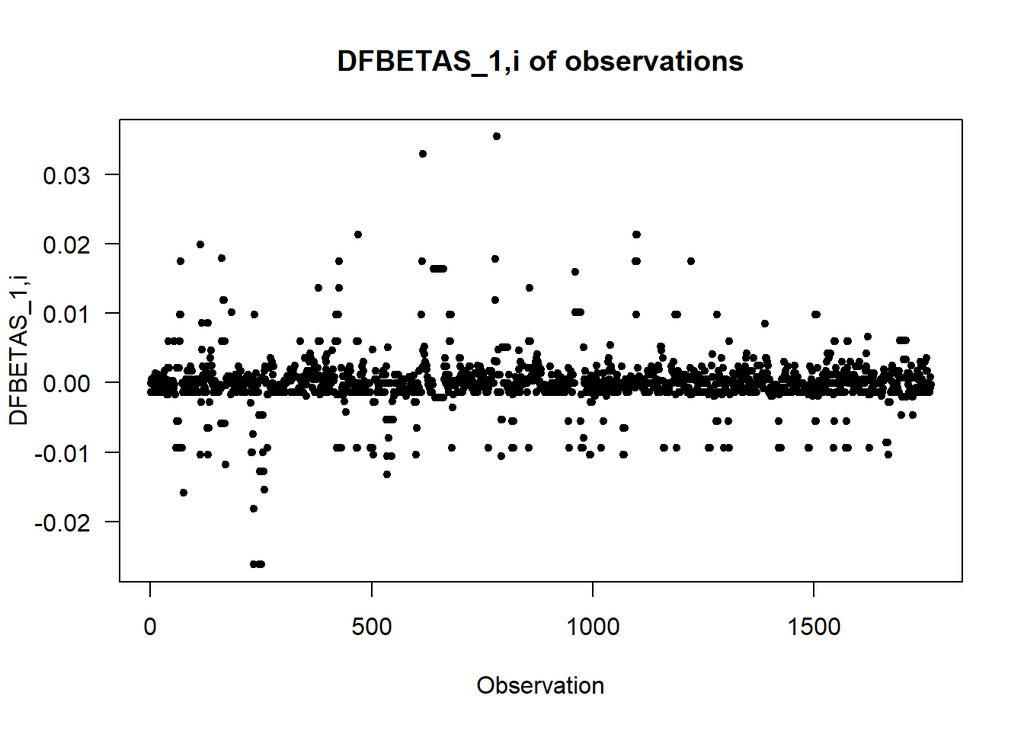

```
        893         281         297         300         707         105
0.018552219 0.013720889 0.013720889 0.013720889 0.013164861 0.011161393
        143        1096         280         193
0.010427320 0.009660681 0.009498511 0.009367056
```

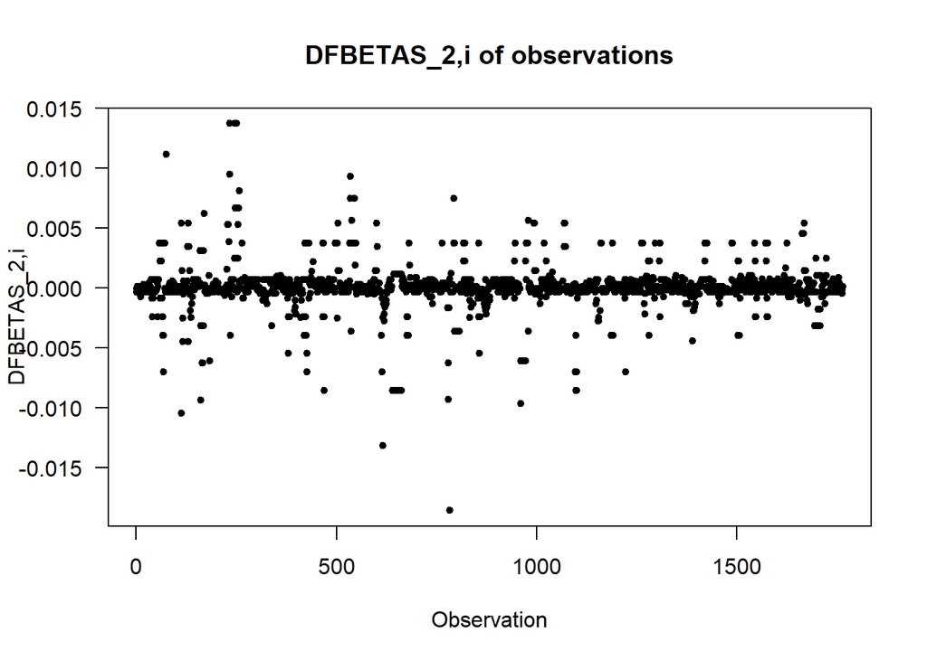

```
      1567        710       1314       1316        167        473        708
0.02939416 0.01801878 0.01801878 0.01801878 0.01612289 0.01612289 0.01612289
       945       1315        453
0.01612289 0.01612289 0.01422699
```

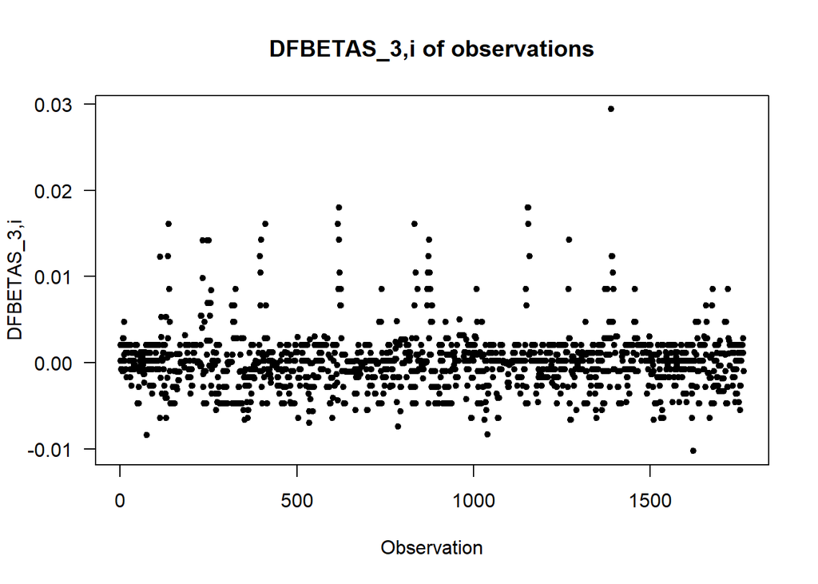

```
       503        893        780        263        499        890        498
0.11984589 0.10862512 0.10182505 0.08380420 0.07479378 0.05456579 0.04776252
       782        355        889
0.04776252 0.03875210 0.03654601
```

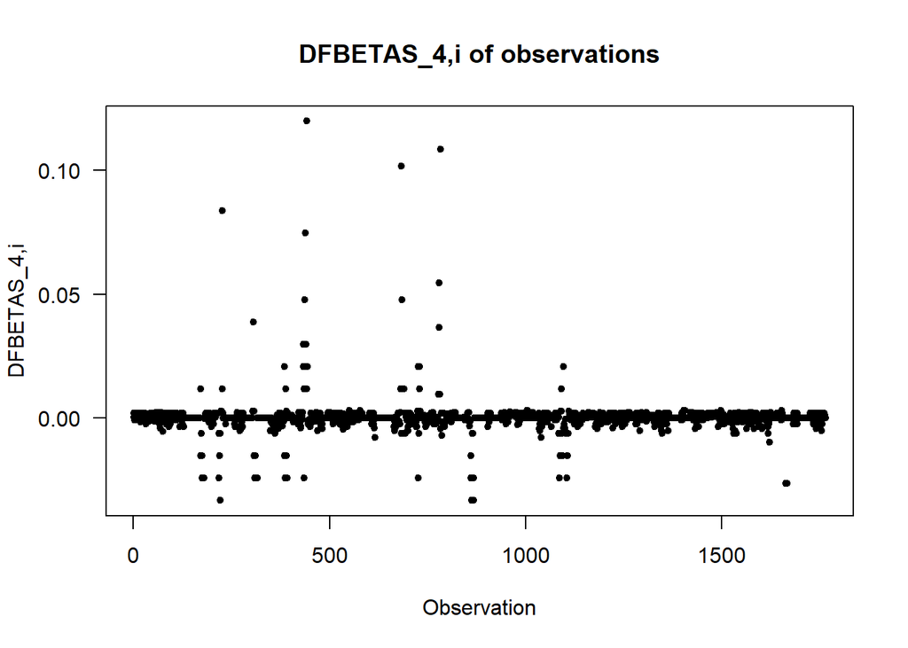

```r
# Influence (DFBETAS)
mymod_inf1 <- dfbeta(mymod1)
for (i in 1:ncol(mymod_inf1)) {
  print(head(sort(abs(mymod_inf1[,i]), decreasing=T), n=10))
  plot(mymod_inf1[,i], pch=20, las=1,
     xlab="Observation", ylab=paste("DFBETAS_", i, ",i", sep=""),
     main=paste("DFBETAS_", i, ",i", " of observations", sep=""))
}
```

```r
# Influence (DFFITS)
mymod_inf2 <- dffits(mymod1)
head(sort(abs(mymod_inf2), decreasing=T), n=10)
```

```
      503       893       780       263       499      1567       890       281
0.5261480 0.5117278 0.4459534 0.3662902 0.3266270 0.2790192 0.2556942 0.2205160
      297       300
0.2205160 0.2205160
```

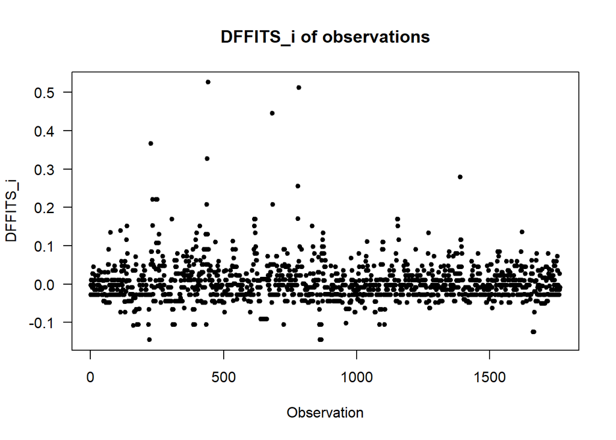

```r
plot(mymod_inf2, pch=20, las=1,
     xlab="Observation", ylab="DFFITS_i",
     main="DFFITS_i of observations")
```

```r
# Influence (Cook's D)
mymod_inf3 <- cooks.distance(mymod1)
head(sort(mymod_inf3, decreasing=T), n=10)
```

```
       503        893        780        263        499       1567        890
0.06806114 0.06458042 0.04913174 0.03328009 0.02650842 0.01902398 0.01629601
       281        297        300
0.01205248 0.01205248 0.01205248
```

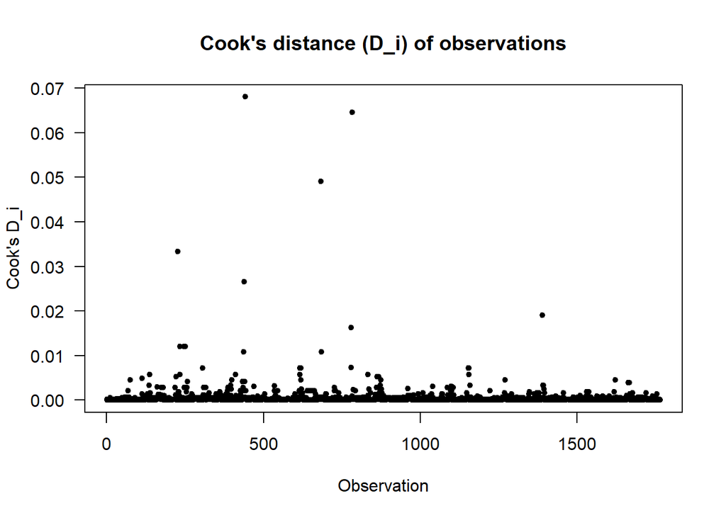

```r
plot(mymod_inf3, pch=20, las=1,
     xlab="Observation", ylab="Cook's D_i",
     main="Cook's distance (D_i) of observations")
```

You can do this with other functions in Python: `get_influence()`, `outlier_test()`, and `OLSInfluence()`. You can look at the largest values numerically or visually:

```python
# Load packages
import plotnine as p9
from statsmodels.stats.outliers_influence import OLSInfluence

# Get index
temp = pd.DataFrame({"Index":mymod1.model.data.row_labels})

# Leverage (hat)
mymod1_lev = mymod1.get_influence().hat_matrix_diag
mymod1_lev = pd.Series(mymod1_lev)
mymod1_lev.index = temp["Index"]
temp["Leverage"] = mymod1_lev
temp["Leverage"].sort_values(ascending=False).head(10)
```

```
757    0.015352
758    0.015352
755    0.015352
730    0.015352
754    0.015352
753    0.015352
756    0.015352
759    0.015352
733    0.015352
745    0.015352
Name: Leverage, dtype: float64
```

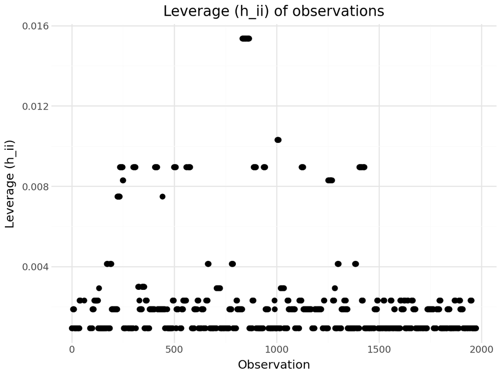

```python
(p9.ggplot(temp, p9.aes(x="Index", y="Leverage")) +
     p9.geom_point(size=2) +
     p9.labs(x="Observation", y="Leverage (h_ii)",
          title="Leverage (h_ii) of observations") +
     p9.theme_minimal()
).show()
```

```python
del mymod1_lev

# Discrepancy (studentized residuals)
mymod1_dis = mymod1.outlier_test()['student_resid']
temp["Discrepancy"] = mymod1_dis
temp["Discrepancy"].sort_values(ascending=False).head(10)
```

[output not shown]

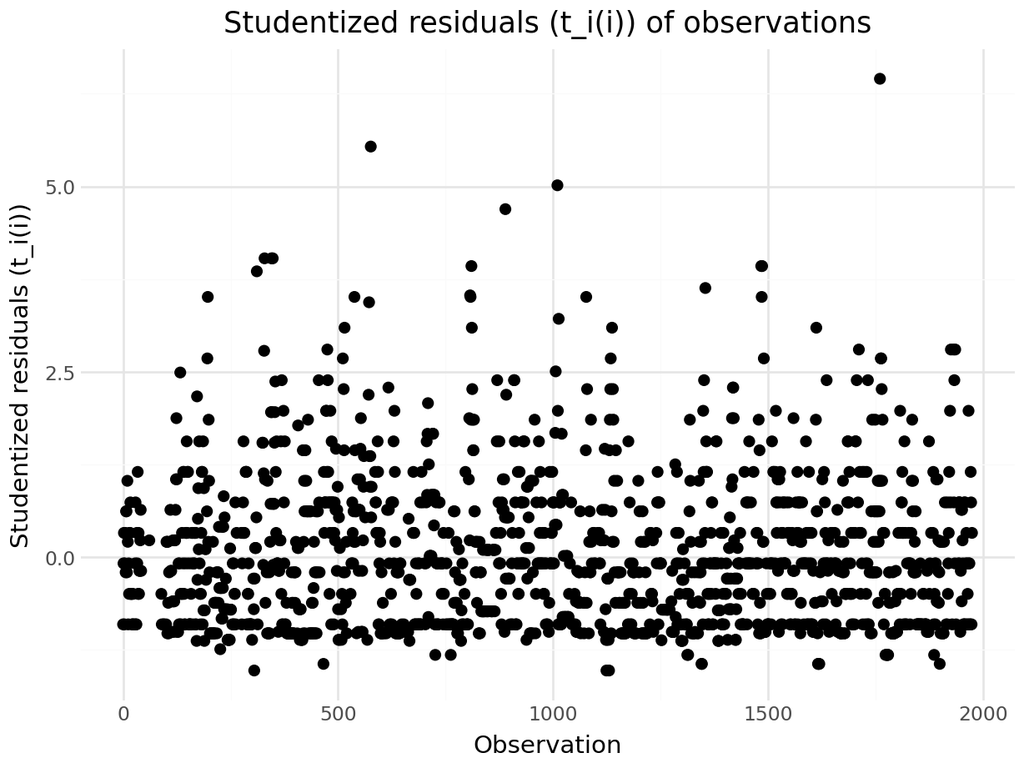

```python
(p9.ggplot(temp, p9.aes(x="Index", y="Discrepancy")) +
     p9.geom_point(size=2) +
     p9.labs(x="Observation", y="Studentized residuals (t_i(i))",
          title="Studentized residuals (t_i(i)) of observations") +
     p9.theme_minimal()
).show()
```

```
Index
892     0.174439
706     0.161481
534     0.104625
1255    0.104625
1256    0.104625
142     0.097481
192     0.087490
889     0.087162
1253    0.085741
1382    0.085741
Name: 0, dtype: float64
Index
280    0.137840
296    0.137840
```

[output cut: 33 more lines]

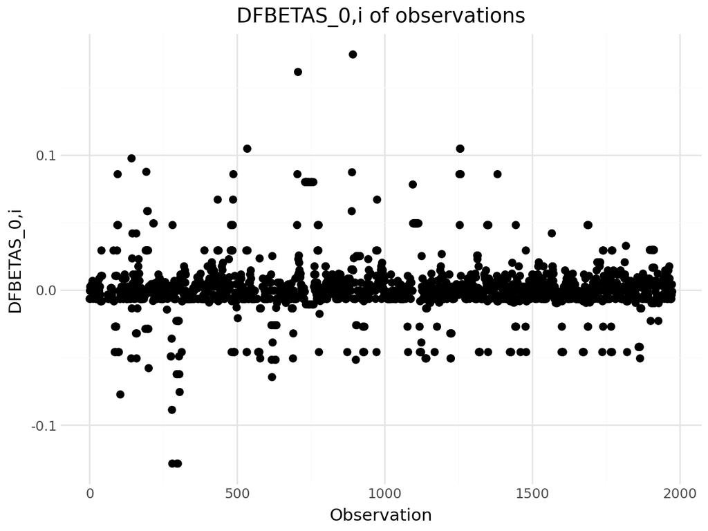

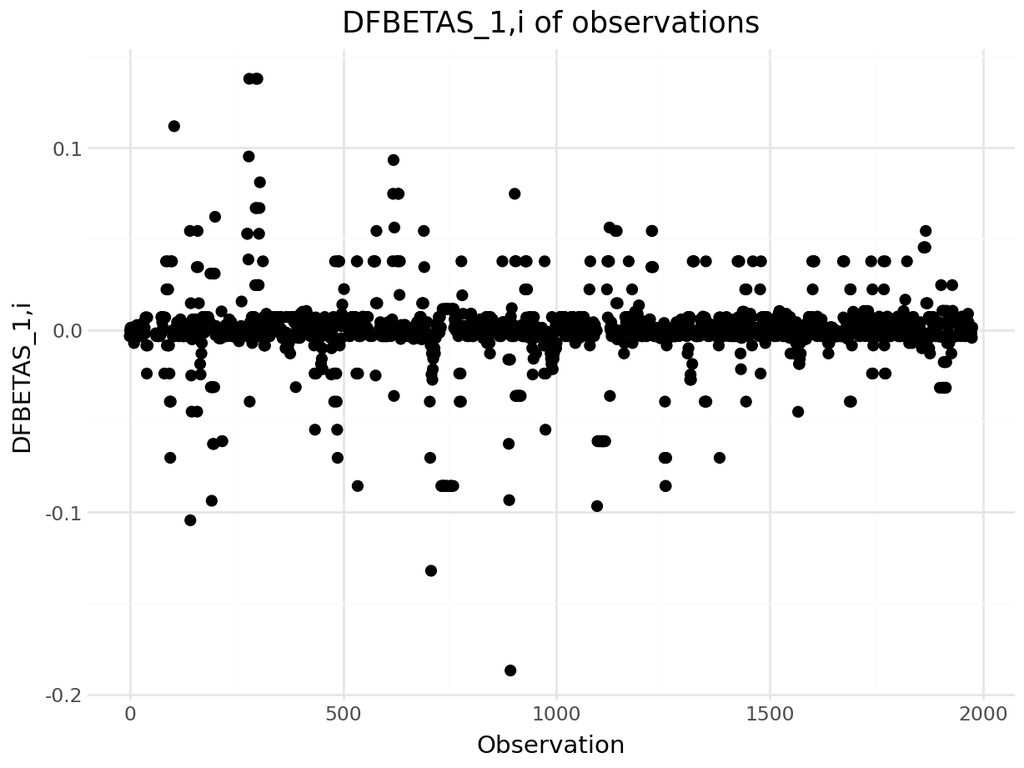

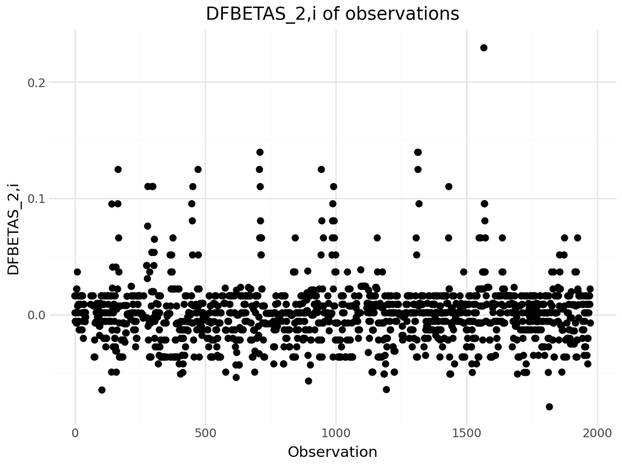

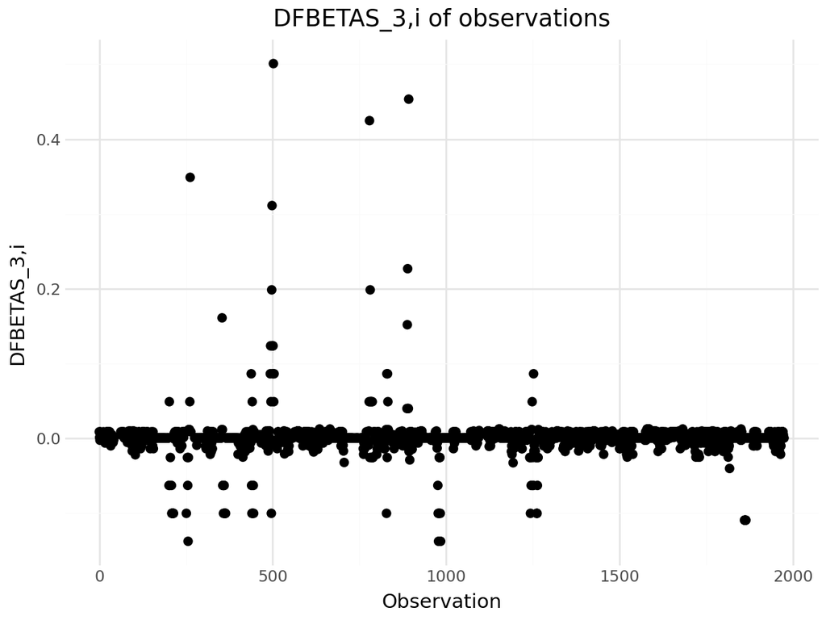

```python
del mymod1_dis

# Influence (DFBETAS)
mymod1_inf1 = OLSInfluence(mymod1).dfbetas
mymod1_inf1 = pd.DataFrame(mymod1_inf1)
mymod1_inf1.index = temp["Index"]
mymod1_inf1["Index"] = mymod1_inf1.index
for i in [0,1,2,3]:
    print(mymod1_inf1[i].sort_values(ascending=False).head(10))
    mymod1_inf1["Coef"] = mymod1_inf1[i]
    (p9.ggplot(mymod1_inf1, p9.aes(x="Index", y="Coef")) +
     p9.geom_point(size=2) +
     p9.labs(x="Observation", y=f"DFBETAS_{i},i",
          title=f"DFBETAS_{i},i of observations") +
     p9.theme_minimal()
    ).show()
```

```python
del i, mymod1_inf1

# Influence (DFFITS)
mymod1_inf2 = OLSInfluence(mymod1).dffits[0]
temp["DFFITS"] = mymod1_inf2
temp["DFFITS"].sort_values(ascending=False).head(10)
```

```
502     0.526148
892     0.511728
779     0.445953
262     0.366290
498     0.326627
1566    0.279019
889     0.255694
296     0.220516
299     0.220516
280     0.220516
Name: DFFITS, dtype: float64
```

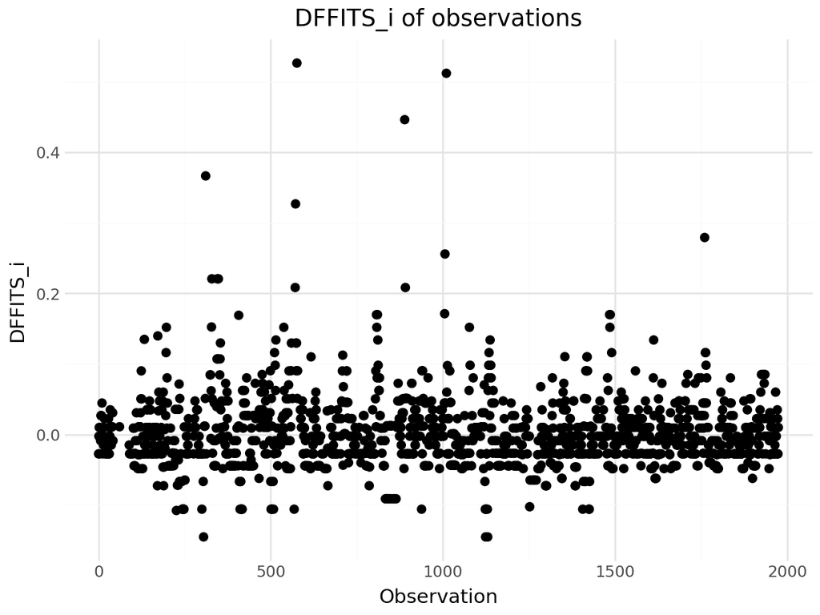

```python
(p9.ggplot(temp, p9.aes(x="Index", y="DFFITS")) +
     p9.geom_point(size=2) +
     p9.labs(x="Observation", y="DFFITS_i",
          title="DFFITS_i of observations") +
     p9.theme_minimal()
).show()
```

```python
del mymod1_inf2

# Influence (Cook's D)
mymod1_inf3 = mymod1.get_influence().cooks_distance[0]
mymod1_inf3 = pd.Series(mymod1_inf3)
mymod1_inf3.index = temp["Index"]
temp["Influence"] = mymod1_inf3
temp["Influence"].sort_values(ascending=False).head(10)
```

```
502     0.068061
892     0.064580
779     0.049132
262     0.033280
498     0.026508
1566    0.019024
889     0.016296
296     0.012052
280     0.012052
299     0.012052
Name: Influence, dtype: float64
```

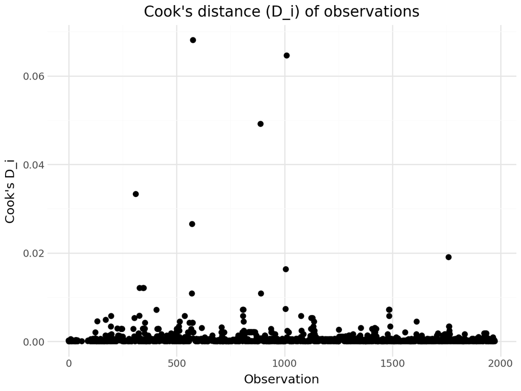

```python
(p9.ggplot(temp, p9.aes(x="Index", y="Influence")) +
     p9.geom_point(size=2) +
     p9.labs(x="Observation", y="Cook's D_i",
          title="Cook's distance (D_i) of observations") +
     p9.theme_minimal()
).show()
```

```python
del mymod1_inf3
```

We can also examine these outlier detection values visually.

In R, the `influencePlot()` function from the `car` package plots each observation on a graph of leverage (hat values) vs. discrepancy (studentized residuals), with the size of the point reflecting its influence (Cook’s distance).

```r
# install.packages("car")
library("car")
```

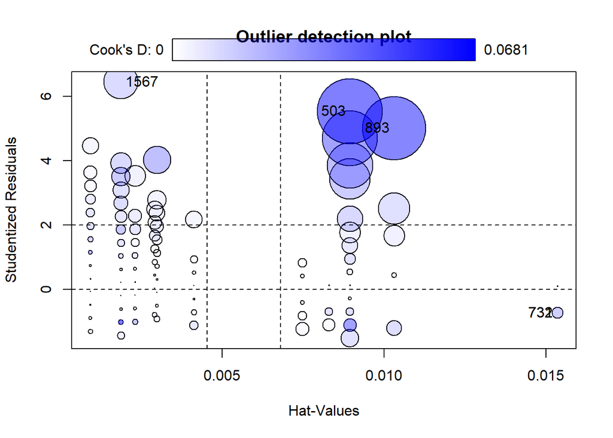

```r
# Summary outlier detection plot
mymod_outs <- influencePlot(mymod1, main="Outlier detection plot")
```

```r
mymod_outs
```

```
        StudRes         Hat      CookD
503   5.5382175 0.008944862 0.06806114
731  -0.7298739 0.015352496 0.00207706
732  -0.7298739 0.015352496 0.00207706
893   5.0156887 0.010301953 0.06458042
1567  6.4523530 0.001866468 0.01902398
```

In Python, the `influence_plot()` function plots each observation on a graph of leverage (hat values) vs. discrepancy (studentized residuals), with the size of the point reflecting its influence (Cook’s distance).

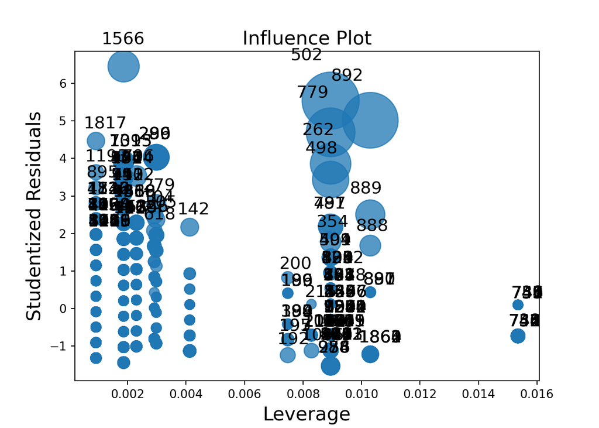

```python
# Load packages
import statsmodels.api as sm

# Summary outlier detection plot
sm.graphics.influence_plot(mymod1)
```

### Remedies

Before determining remedies for dealing with outliers, we must first discuss the reasons why they may be caused. Statistically, some extreme observations would be expected due to random sampling, so we must consider this possibility. More fundamentally, outliers could be either **valid observations** or **observations with errors**. Let’s consider the latter first.

Sometimes there are *errors* in the data. This is a common (if not frequent) occurrence that you will have to deal with. Error can be introduced into the dataset at any point in the process.

- There could be an error in the original data collection or measurement process, such as a sensor that malfunctions or a respondent selecting the wrong option. In this situation, there is not much that an analyst can do except to remove the erroneous observation, except make sure to collect more accurate data in the future.
- There could be an error in the data coding, especially when data are being converted in form (such as from paper to computer). For example, a coder might misinterpret a mark on a paper survey. In this situation, the analyst should try to go back to the original data source (if possible) and confirm that no transcription errors were made or fix any such errors.
- There could be an error in the data manipulation and calculation process; this would be caused by the analyst. These errors should be fixed by going through and double-checking all steps of the data preparation and analysis process. Including such checks along the way is usually helpful, as is having other analysts check your code and calculations.

Basically, if the error can be fixed, it should be. If the error cannot be fixed, the observation(s) should be removed from the dataset and the analysis.

Often, outliers are actually *valid observations* that do not contain any (identifiable) errors. These instances are more difficult to deal with.

- It could be that your assumed relationship/theory/hypothesis is wrong, and (thus) that your model is misspecified. This could be due to not including all of the relevant factors (missing variables), there being a non-linearity that you are not accounting for, or that the entire model form is wrong (e.g., linear regression is the wrong approach). In these situations, you will need to take a step back and reconsider your entire analysis approach.
- It could also be that the data are valid and the model is valid, but it is being applied to the wrong data. In this case, your outliers may belong to a fundamentally different group or because the relationship you are modeling doesn’t hold for those observations or that group. In these situations, you may be right to remove these outliers, thus narrowing your focus on a more consistent behavior or phenomena, but you must clearly justify why you are doing so.

Ultimately, your remedy for outliers depends upon your understanding of the dataset, data collection methods, the data manipulation and calculation process, and the underlying phenomenon you are trying to analyze. It is usually better to fix the data (or your theory/model) rather than removing observations, but this may not always be possible.

#### Examples

Recall our outlier detection statistics and plots. It appears we may have 5 outliers, based measures of leverage, discrepancy, and influence.

```r
# Identify potential outliers in model
mymod1$model[row.names(mymod_outs),]
```

```
     MODE_TOT HHNPER HHINC_Above HHINC_Unknown
503        18      2           0             1
731         2      5           1             0
732         2      5           1             0
893        17      1           0             1
1567       20      2           1             0
```

```r
# Inspect potential outliers in original dataset
# mydf[row.names(mymod_outs),]
```

```python
# Inspect potential outliers in original dataset
tcol = [mymod1.model.endog_names] + mymod1.model.exog_names
tcol.remove('Intercept')
mydf.loc[[502,730,732,892,1566], tcol]
```

```
      MODE_TOT  HHNPER  HHINC_Above  HHINC_Unknown
502       18.0       2          0.0            1.0
730        2.0       5          1.0            0.0
732        2.0       5          1.0            0.0
892       17.0       1          0.0            1.0
1566      20.0       2          1.0            0.0
```

```python
del tcol
```

For some reason, these observations appear to be significantly different and influential. Perhaps some of the data may be wrong or contain errors for these observations. Let’s remove them and re-estimate the model. Then, let’s compare our new model (without outliers) with our original model estimation results.

```r
# Remove outliers
mydf2 <- mydf[!(row.names(mydf) %in% row.names(mymod_outs)),]

# Re-estimate model
# mymod3 <- lm(MODE_TOT ~ HHNPER + HHINC_Above + HHINC_Unknown, data=mydf2)
mymod3 <- update(mymod1, data=mydf2)

# Compare models
summary(mymod1)
```

```
Call:
lm(formula = MODE_TOT ~ HHNPER + HHINC_Above + HHINC_Unknown,
    data = mydf)

Residuals:
    Min      1Q  Median      3Q     Max
-3.6992 -2.2027 -0.2513  1.5041 15.5041

Coefficients:
              Estimate Std. Error t value Pr(>|t|)
(Intercept)    4.69186    0.20445  22.948   <2e-16 ***
HHNPER        -0.24460    0.09997  -2.447   0.0145 *
HHINC_Above    0.29324    0.12961   2.262   0.0238 *
HHINC_Unknown  0.49653    0.24126   2.058   0.0397 *
---
Signif. codes:  0 '***' 0.001 '**' 0.01 '*' 0.05 '.' 0.1 ' ' 1

Residual standard error: 2.433 on 1761 degrees of freedom
  (210 observations deleted due to missingness)
Multiple R-squared:  0.007, Adjusted R-squared:  0.005308
F-statistic: 4.138 on 3 and 1761 DF,  p-value: 0.006206
```

```r
summary(mymod3)
```

```
Call:
lm(formula = MODE_TOT ~ HHNPER + HHINC_Above + HHINC_Unknown,
    data = mydf2)

Residuals:
    Min      1Q  Median      3Q     Max
-3.4722 -2.2062 -0.2619  1.5321 11.5278

Coefficients:
              Estimate Std. Error t value Pr(>|t|)
(Intercept)    4.61807    0.20155  22.913   <2e-16 ***
HHNPER        -0.20595    0.09873  -2.086   0.0371 *
HHINC_Above    0.26169    0.12626   2.073   0.0384 *
HHINC_Unknown  0.26602    0.23676   1.124   0.2613
---
Signif. codes:  0 '***' 0.001 '**' 0.01 '*' 0.05 '.' 0.1 ' ' 1

Residual standard error: 2.368 on 1756 degrees of freedom
  (210 observations deleted due to missingness)
Multiple R-squared:  0.004503,  Adjusted R-squared:  0.002803
F-statistic: 2.648 on 3 and 1756 DF,  p-value: 0.04753
```

```python
# Remove outliers
mydf2 = mydf.drop([502,730,732,892,1566])

# Re-estimate model
# mymod3 = smf.ols("MODE_TOT ~ HHNPER + HHINC_Above + HHINC_Unknown", data=mydf2).fit()
mymod3 = smf.ols(mymod1.model.formula, data=mydf2).fit()

# Compare models
mymod1.summary()
```

OLS Regression Results

| Dep. Variable: | MODE_TOT | R-squared: | 0.007 |
| --- | --- | --- | --- |
| Model: | OLS | Adj. R-squared: | 0.005 |
| Method: | Least Squares | F-statistic: | 4.138 |
| Date: | Sat, 04 Oct 2025 | Prob (F-statistic): | 0.00621 |
| Time: | 13:56:02 | Log-Likelihood: | -4071.5 |
| No. Observations: | 1765 | AIC: | 8151. |
| Df Residuals: | 1761 | BIC: | 8173. |
| Df Model: | 3 |  |  |
| Covariance Type: | nonrobust |  |  |

|  | coef | std err | t | P>\|t\| | [0.025 | 0.975] |
| --- | --- | --- | --- | --- | --- | --- |
| Intercept | 4.6919 | 0.204 | 22.948 | 0.000 | 4.291 | 5.093 |
| HHNPER | -0.2446 | 0.100 | -2.447 | 0.015 | -0.441 | -0.049 |
| HHINC_Above | 0.2932 | 0.130 | 2.262 | 0.024 | 0.039 | 0.547 |
| HHINC_Unknown | 0.4965 | 0.241 | 2.058 | 0.040 | 0.023 | 0.970 |

| Omnibus: | 468.584 | Durbin-Watson: | 1.277 |
| --- | --- | --- | --- |
| Prob(Omnibus): | 0.000 | Jarque-Bera (JB): | 1242.724 |
| Skew: | 1.395 | Prob(JB): | 1.40e-270 |
| Kurtosis: | 6.019 | Cond. No. | 9.89 |

Notes:  
[1] Standard Errors assume that the covariance matrix of the errors is correctly specified.

```python
mymod3.summary()
```

OLS Regression Results

| Dep. Variable: | MODE_TOT | R-squared: | 0.005 |
| --- | --- | --- | --- |
| Model: | OLS | Adj. R-squared: | 0.003 |
| Method: | Least Squares | F-statistic: | 2.648 |
| Date: | Sat, 04 Oct 2025 | Prob (F-statistic): | 0.0475 |
| Time: | 13:56:02 | Log-Likelihood: | -4012.5 |
| No. Observations: | 1760 | AIC: | 8033. |
| Df Residuals: | 1756 | BIC: | 8055. |
| Df Model: | 3 |  |  |
| Covariance Type: | nonrobust |  |  |

|  | coef | std err | t | P>\|t\| | [0.025 | 0.975] |
| --- | --- | --- | --- | --- | --- | --- |
| Intercept | 4.6181 | 0.202 | 22.913 | 0.000 | 4.223 | 5.013 |
| HHNPER | -0.2060 | 0.099 | -2.086 | 0.037 | -0.400 | -0.012 |
| HHINC_Above | 0.2617 | 0.126 | 2.073 | 0.038 | 0.014 | 0.509 |
| HHINC_Unknown | 0.2660 | 0.237 | 1.124 | 0.261 | -0.198 | 0.730 |

| Omnibus: | 354.986 | Durbin-Watson: | 1.273 |
| --- | --- | --- | --- |
| Prob(Omnibus): | 0.000 | Jarque-Bera (JB): | 670.327 |
| Skew: | 1.217 | Prob(JB): | 2.76e-146 |
| Kurtosis: | 4.794 | Cond. No. | 9.93 |

Notes:  
[1] Standard Errors assume that the covariance matrix of the errors is correctly specified.

Notice what happened to the model goodness-of-fit by removing only 5 observations. What does that mean about the fit of these observations to the rest of the dataset?

## Review

- Can you Identify potential outliers using:
  - Leverage?
  - Discrepancy (studentized residuals)?
  - Influence (DFBETAS, DFFITS, Cook’s D)?
  - A combination of the above methods?
- Can you determine the appropriate remedy for outliers, depending upon your understanding of the dataset, data collection process, and analytic methods?

**END**